# Html_IBM_Cognitive_Computing

## Data Load

```python
# Loading data table from csv files.
import pandas as pd

df = pd.read_csv('https://storage.googleapis.com/datalynn-datasets/interview-challenge/technology/IBM_Cognitive_Computing/MedicalFeedback.csv')
```

## Question 1

**Scenario**: You notice that several feedback entries in the `Medical_Feedback` table have missing `Feedback_Rating` values. However, you remember that a recent marketing survey (stored in another table) might contain some of these missing ratings.

**Question**: How would you integrate the `Medical_Feedback` table with the marketing survey to fill the missing ratings?

Since we are only given one table, from the question, we assume that we should have seconde table named **Marketing_Survey** containing the missing Feedback_Rating values. Both Medical_Feedback and Marketing_Survey should have some common columns to join them together, such as Feedback_ID or Customer_Name and Product_Name.

Let's assume that Marketing_Survey has the following columns:

- Customer_Name
- Product_Name
- Feedback_Rating

Because we don't have the access to another table, we describe our solution in the following roadmap.

### Solution roadmap

1. Import the Pandas Library

Start by importing the Pandas library, which is essential for data manipulation in Python.

2. Load the Data Tables

Load the `Medical_Feedback` and `Marketing_Survey` tables into Pandas DataFrames. This assumes you have the data stored in CSV files.

3. Check for Missing Values

Before you proceed with merging the tables, examine how many entries in the `Feedback_Rating` column of the `Medical_Feedback` table are missing.

4. Perform the Merge

Merge the `Medical_Feedback` DataFrame with the `Marketing_Survey` DataFrame. Use columns like `Customer_Name` and `Product_Name` as the keys to join the tables. You'll want to use an "outer" join to keep all entries from both tables.

5. Fill in the Missing Ratings

After merging, some entries in `Feedback_Rating` will still be missing. You can fill these missing values with corresponding ratings from the `Marketing_Survey` table, if available.

6. Remove Redundant Columns

Once you've filled the missing ratings, you'll have an extra column from the `Marketing_Survey` table that you used temporarily to fill missing values. Drop this extra column as it's no longer needed.

7. Verify the Data

After you've made these changes, inspect the data again to ensure that all missing values in the `Feedback_Rating` column have been properly filled.

8. Save the Updated Table

Finally, save the updated `Medical_Feedback` table with the filled-in missing ratings into a new CSV file or overwrite the existing one.

## Question 2

**Scenario**: Your team is curious about the distribution of feedback types over time.

**Question**: Based on the `Timestamp` and `Feedback_Type`, can you analyze the monthly trend of each feedback type and predict which month might see the highest number of 'Bug' type feedbacks?

### Hints:

1. Datetime Parsing

Start by converting the `Timestamp` column to a datetime data type if it isn't already. This will enable you to easily extract the month and year for each feedback, which are essential for analyzing the monthly trend.

2. Grouping and Aggregation

Group the data by 'Year', 'Month', and 'Feedback_Type', and then count the occurrences. This will give you a summarized DataFrame showing the number of each type of feedback for each month in each year.

3. Visualization

Visualize the monthly trend of 'Bug' type feedbacks by plotting the aggregated data. It's helpful to plot each year's data as a separate line on the same graph to observe any seasonal or temporal patterns.

By following these hints, you should be able to analyze the distribution of feedback types over time and make a prediction about the month likely to have the highest number of 'Bug' type feedbacks.

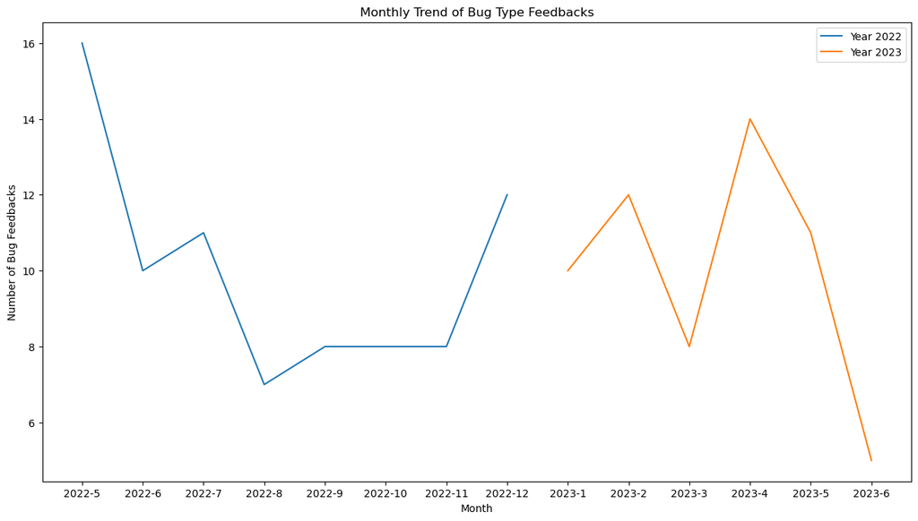

```
The month that might see the highest number of 'Bug' type feedbacks is 4.
```

```python
import pandas as pd
import matplotlib.pyplot as plt

# Step 1: Convert 'Timestamp' to datetime type if it isn't
df_medical_feedback = df
df_medical_feedback['Timestamp'] = pd.to_datetime(df_medical_feedback['Timestamp'])

# Step 2: Extract the month and year from the 'Timestamp' column for easier analysis
df_medical_feedback['Year'] = df_medical_feedback['Timestamp'].dt.year
df_medical_feedback['Month'] = df_medical_feedback['Timestamp'].dt.month

# Step 3: Group by 'Year', 'Month' and 'Feedback_Type', then count the occurrences
grouped_df = df_medical_feedback.groupby(['Year', 'Month', 'Feedback_Type']).size().reset_index(name='Count')

# Step 4: Filter the data for 'Bug' type feedbacks
bug_df = grouped_df[grouped_df['Feedback_Type'] == 'Bug']

# Step 5: Visualize the monthly trends for 'Bug' type feedbacks
plt.figure(figsize=(15, 8))
for year in bug_df['Year'].unique():
    subset = bug_df[bug_df['Year'] == year]
    plt.plot(f"{year}-" + subset['Month'].astype(str), subset['Count'], label=f'Year {year}')

plt.xlabel('Month')
plt.ylabel('Number of Bug Feedbacks')
plt.title('Monthly Trend of Bug Type Feedbacks')
plt.legend()
plt.show()

# Optional: If you'd like to predict the month with the highest number of 'Bug' feedbacks,
# you can simply find the month with the highest average 'Bug' feedbacks in the past.

# Step 6: Calculate the mean 'Bug' feedbacks for each month across all years
mean_bug = bug_df.groupby('Month')['Count'].mean().reset_index(name='Mean_Count')

# Step 7: Find the month with the highest mean 'Bug' feedbacks
highest_month = mean_bug.loc[mean_bug['Mean_Count'].idxmax(), 'Month']

print(f"The month that might see the highest number of 'Bug' type feedbacks is {highest_month}.")
```

## Question 3

**Scenario**: Your product team is keen on prioritizing feedbacks. They believe that understanding the urgency is crucial.

**Question**: Build a predictive model using the available features in the `Medical_Feedback` table to predict the `Urgency_Predicted` of each feedback. Remember to justify your choice of model.

### Hints:

1. **Data Preprocessing**: Begin by loading the data into a DataFrame and conducting preliminary data preprocessing. This could involve handling missing values and dropping irrelevant columns. Consider using libraries like `pandas` for this.
2. **Feature Engineering**: Since you have both numerical and categorical data, focus on how to convert these into a format that can be fed into a machine learning model. For text and image features, you may need additional preprocessing or even feature extraction techniques. Don't forget to separate your features (`X`) from the target variable (`y`).
3. **Model Selection and Training**: Choose a machine learning model that is suited for classification tasks. Train this model with your processed features and evaluate its performance using metrics such as accuracy or F1-score. Libraries like `scikit-learn` provide various models and metrics that you can use.

```python
# Importing necessary libraries
import pandas as pd
import numpy as np
from sklearn.model_selection import train_test_split
from sklearn.preprocessing import LabelEncoder
from sklearn.ensemble import RandomForestClassifier
from sklearn.metrics import accuracy_score, classification_report

df_model = df
# Data Preprocessing
# Drop irrelevant columns
df_model = df_model.drop(['Feedback_ID', 'Product_Name', 'Customer_Name', 'Timestamp', 'Image_Attachment'], axis=1)

# Handle missing values
df_model = df_model.dropna()

# Convert categorical variables into numerical ones
label_encoder = LabelEncoder()
df_model['Feedback_Type'] = label_encoder.fit_transform(df_model['Feedback_Type'])
df_model['Urgency_Predicted'] = label_encoder.fit_transform(df_model['Urgency_Predicted'])

# Text Preprocessing
# For simplicity, we will drop the 'Feedback_Text' column.
# In a real-world scenario, you would preprocess this text data and convert it into a format suitable for the model.
df_model = df_model.drop('Feedback_Text', axis=1)

# Feature Selection
X = df_model.drop('Urgency_Predicted', axis=1)
y = df_model['Urgency_Predicted']

# Data Splitting
X_train, X_test, y_train, y_test = train_test_split(X, y, test_size=0.2, random_state=42)

# Model Selection
# We will use Random Forest Classifier as it usually works well for classification tasks and does not require scaling of data.
clf = RandomForestClassifier(random_state=42)

# Model Training
clf.fit(X_train, y_train)

# Model Evaluation
y_pred = clf.predict(X_test)
accuracy = accuracy_score(y_test, y_pred)
print("Accuracy:", accuracy)
print("Classification Report:\n", classification_report(y_test, y_pred))

# Model Prediction
# Now you can use clf.predict() to make predictions on new data.
```

```
Accuracy: 1.0
Classification Report:
               precision    recall  f1-score   support

           0       1.00      1.00      1.00         1
           1       1.00      1.00      1.00       167
           2       1.00      1.00      1.00        32

    accuracy                           1.00       200
   macro avg       1.00      1.00      1.00       200
weighted avg       1.00      1.00      1.00       200
```

### Justification for Model Choice:

We have chosen the Random Forest Classifier model because it is a robust and versatile model that usually works well for classification tasks. It also does not require the data to be scaled and can handle non-linear relationships between the features and the target variable. Additionally, Random Forest helps to avoid overfitting, which is a common problem with decision trees.

## Question 4

**Scenario**: A consulting team at IBM is preparing a presentation for a new potential client in Healthcare Marketing for Cancer research in India. They need insights drawn from the feedback received about IBM's medical products.

**Question**: Using the `Feedback_Text` and `Image_Attachment`, can you identify any recurring themes or patterns that might be of interest to the consulting team? Furthermore, can you use this information to propose a potential feature or enhancement for our medical products tailored to the Cancer research industry in India?

### Hints:

1. **Text Analysis**: Start by focusing on the `Feedback_Text` column in the data table. Consider techniques like Topic Modeling or Keyword Extraction to identify recurring themes or patterns in the text feedback. Libraries like `sklearn` can be useful for this.
2. **Image Analysis**: If the `Image_Attachment` column contains images, you might want to use image processing techniques to extract meaningful information from them. For instance, you can employ Object Detection or Image Classification algorithms to identify recurring objects or themes in the images.
3. **Combine Insights**: After obtaining insights from both textual and image data, aim to combine these to gain a more holistic understanding. You can then use these combined insights to propose new features or enhancements specifically tailored to the Cancer research industry in India. Be attentive to specific needs or complaints that may be unique to this context.

```python
# Import Required Libraries
import pandas as pd
from sklearn.feature_extraction.text import CountVectorizer
from sklearn.decomposition import LatentDirichletAllocation
from textblob import TextBlob
from PIL import Image
# Import other image processing libraries if required


# Text Analysis
# -------------

# Vectorize the 'Feedback_Text' column
vectorizer = CountVectorizer(max_df=0.95, min_df=2, stop_words='english')
text_vectorized = vectorizer.fit_transform(df['Feedback_Text'])

# Perform LDA (Latent Dirichlet Allocation) for Topic Modeling
lda = LatentDirichletAllocation(n_components=5, random_state=42)
lda.fit(text_vectorized)

# Display Topics
feature_names = vectorizer.get_feature_names_out()
for topic_idx, topic in enumerate(lda.components_):
    print(f"Topic #{topic_idx+1}:")
    print(" ".join([feature_names[i] for i in topic.argsort()[:-10 - 1:-1]]))

# Perform Sentiment Analysis using TextBlob
df['Sentiment'] = df['Feedback_Text'].apply(lambda x: TextBlob(x).sentiment.polarity)

# Image Analysis
# --------------

# Placeholder function to process images
def process_images(image):
    # Process the image and return identified objects or themes
    # Implement your image processing logic here
    return "example_theme"

# Apply the image processing function to the 'Image_Attachment' column
df['Image_Themes'] = df['Image_Attachment'].apply(process_images)

# Combine Insights
# ----------------

# Combine topics and image themes to understand recurring patterns.
# At this stage, you may require some manual intervention to map the topics and themes to potential features.

# Based on the recurring themes, you can propose features or enhancements tailored for the Cancer research industry in India.
# For example, if a theme around "automating cell image analysis" recurs, a feature around this could be proposed.
```

```
Topic #1:
features wish product good bug user friendly
Topic #2:
bug features wish product good user friendly
Topic #3:
wish features product good bug user friendly
Topic #4:
good product features wish bug user friendly
Topic #5:
friendly user features wish product good bug
```